# STA141A Project

William Yu

2024-03-10

# ABSTRACT

In this report, I discuss the analysis of neural activity data obtained from experiments conducted on mice in a study by Steinmetz et al. (2019). The data set of these experiments comprise of 18 sessions with a set number of trials where mice made decisions based on a visual stimuli. The objective of this report is to build a predictive model for trial outcomes.

The initial was exploratory data analysis of the experiments. To do this I looked at the data structure across sessions; this includes looking at the varying number of neurons in each session, the number of trials in each session, success rate of the trials across the sessions, and the number of unique brain areas.

Session 10 was the primary session who’s data was used to build the end model.

The next step was data integration. I looked further into the number of neurons in each session, the average spike rate over each session, and the individual success rates of each session. Then, I visually graphed the success rates across each session and mouse, brain areas with neurons recorded in each session, and the change of overall neuron spike rate over time for each session and mouse.

The results show that Model 2 outperforms Model 1 and a bias guess. The ROC curves and AUC values illustrate the discrimination ability of each model, with higher AUC values indicating better performance.

# SECTION 1 INTRODUCTION

This project aims to analyze a data set from a study conducted by Steinmetz et al. (2019). Within the study, Steinmetz et al. focus on experiments performed on 10 mice over 39 sessions. Visual stimuli were presented to the mice on two screens, with varying contrast levels. The mice made decisions based on these stimuli using a wheel, receiving feedback accordingly. Each trial is characterized by feedback type, left and right contrast levels, time bins for spike counts, spike counts of neurons, and brain area. A total of 18 RDS files are provided, each containing data from one session.

This project’s overarching goal is to build a predictive model for trial outcomes using neural activity data and stimuli.

This project felt particularly challenging due to the structure of the data being a folder of .rds files. I found this to be a daunting task to work with at first. Initially, I attempted to read in the data, then put it in a matrix so it would be easier to work with. However, I eventually found that working with the data directly from the folder was easiest.

Due to the large data set with the 18 sessions having many trials within them, I decided it was best to choose a singular session to work with instead of iterating through them all. As such, I mainly focused on session 10 to build the model. This made it so my code ran smoother and would not be excessively large. I chose session 10 for reasons later discussed in this report.

Unfortunately, in the end, I was unable to find a perfect model to predict trial outcomes.

# SECTION 2 EXPLORATORY ANALYSIS

The first part of this model was exploring the data set.

```
## [1] "Trials Per Session:"
```

```
##  [1] 114 251 228 249 254 290 252 250 372 447 342 340 300 268 404 280 224 216
```

```
## [1] "Success Rate:"
```

```
## [1] 0.7100964
```

```
## # A tibble: 18 × 2
##    session_id unique_area
##         <int>       <int>
##  1          1           8
##  2          2           5
##  3          3          11
##  4          4          11
##  5          5          10
##  6          6           5
##  7          7           8
##  8          8          15
##  9          9          12
## 10         10          13
## 11         11           6
## 12         12          12
## 13         13          15
## 14         14          10
## 15         15           8
## 16         16           6
## 17         17           6
## 18         18          10
```

```
## [1] 62
```

```
## # A tibble: 18 × 2
##    session_id `sum(region_count)`
##         <int>               <int>
##  1          1                 734
##  2          2                1070
##  3          3                 619
##  4          4                1769
##  5          5                1077
##  6          6                1169
##  7          7                 584
##  8          8                1157
##  9          9                 788
## 10         10                1172
## 11         11                 857
## 12         12                 698
## 13         13                 983
## 14         14                 756
## 15         15                 743
## 16         16                 474
## 17         17                 565
## 18         18                1090
```

Within this section, the 18 x 2 tibble directly above displays the number of neurons in its respective session. The number of trials per session, the success rate across all sessions, and the number of unique brain areas recorded for each session.

Finding the total number of trials per session is important due to sampling size significance. Because session 10 had the most number of trials, I chose this session to help build my model. Of the trials, because of its sample size, session 10 had the most statistical power, can be generalized most easily, and made it easier to identify patterns within the data.

Next, I considered the success rates of the trials due to the fact that it displays how effective the overal experiment was. For this experiment, it was found to have a success rate of 71.01%. This is significant for both interpreting the data which helped to provide context of the neural activity, but also gives an insight to what the trials/sessions will look like when I eventually look at a specific trial. Additionally, this is a fairly high success rate indicating good quality of the experiment design; if the success rate were low, this could indicate a poor experiment set up or an error in the data collection making the data less useful.

Additionally, feedback types and stimuli conditions were also found for the 18 sessions. The code and output of session 1 can be found in the appendix (under exploratory analysis).

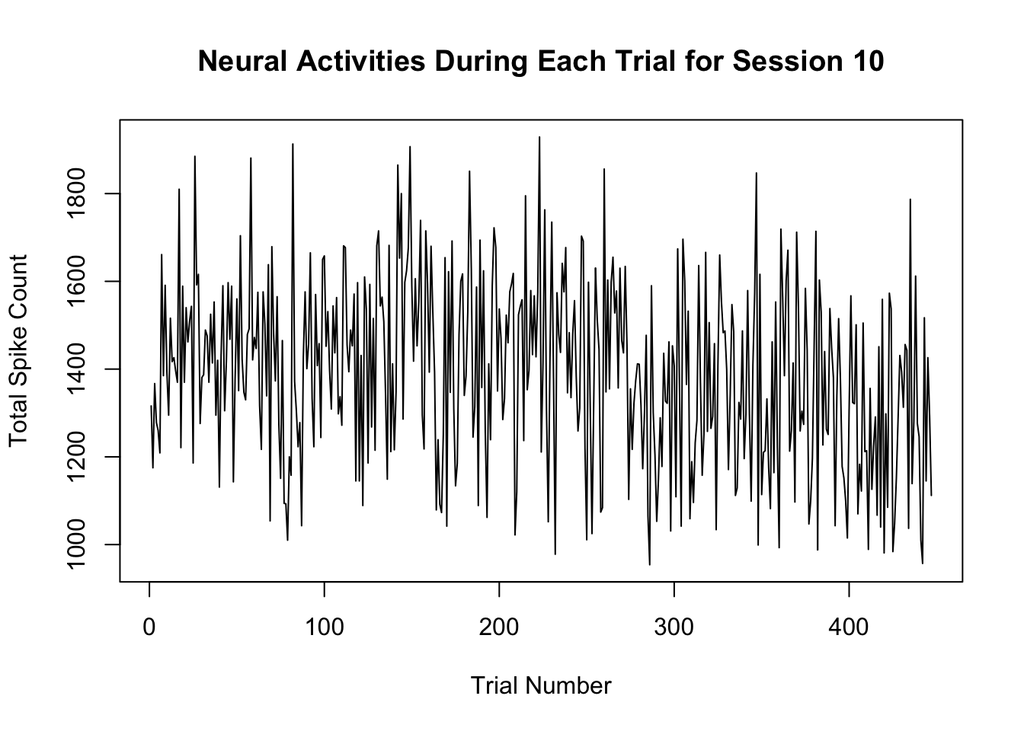

Furthermore, the above graph displays the neural activities for session 10 above. There is great variation in the graph changing/zig-zagging greatly with every trial.

(Full code in Appendix: Exploratory Analysis)

# SECTION 3 DATA INTEGRATION

In this section, I looked at data integration to enhance prediction performance in Part 4.

To do this, I visually looked at the 18 sessions and tried to identify common patterns or features. Additionally, I looked more closely at session 10 as it appeared to be the most likely session that I will work with

```
## # A tibble: 18 × 2
##    session_id mean_session_spike
##         <int>              <dbl>
##  1          1              1.54
##  2          2              1.27
##  3          3              2.23
##  4          4              0.842
##  5          5              1.12
##  6          6              0.663
##  7          7              1.42
##  8          8              1.66
##  9          9              1.59
## 10         10              1.19
## 11         11              1.25
## 12         12              1.66
## 13         13              2.46
## 14         14              1.01
## 15         15              1.46
## 16         16              1.05
## 17         17              1.17
## 18         18              1.10
```

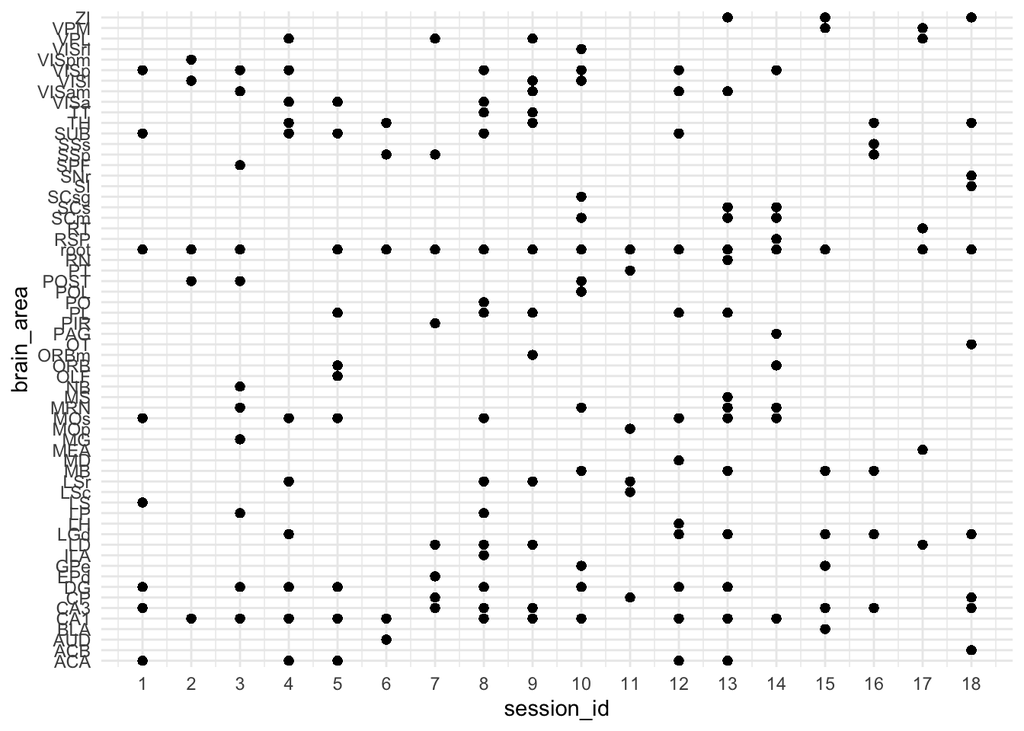

```
## # A tibble: 18 × 2
##    session_id success_rate
##    <fct>             <dbl>
##  1 1                 0.605
##  2 2                 0.633
##  3 3                 0.662
##  4 4                 0.667
##  5 5                 0.661
##  6 6                 0.741
##  7 7                 0.671
##  8 8                 0.644
##  9 9                 0.685
## 10 10                0.620
## 11 11                0.795
## 12 12                0.738
## 13 13                0.797
## 14 14                0.694
## 15 15                0.765
## 16 16                0.718
## 17 17                0.830
## 18 18                0.806
```

```
## # A tibble: 4 × 2
##   mouse_name success_rate
##   <chr>             <dbl>
## 1 Cori              0.639
## 2 Forssmann         0.687
## 3 Hench             0.684
## 4 Lederberg         0.761
```

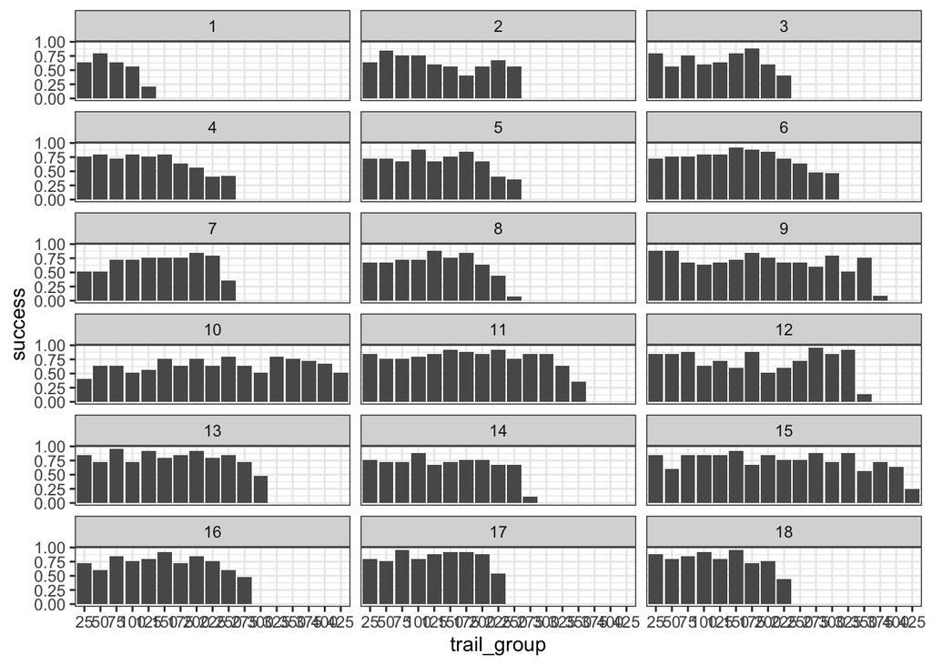

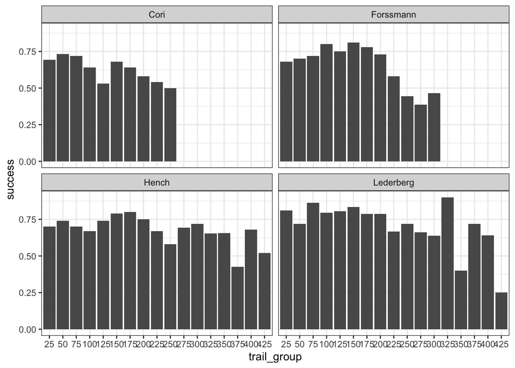

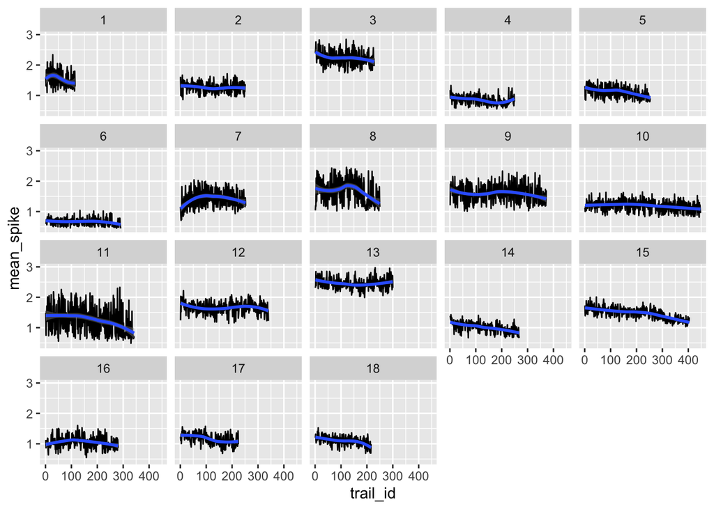

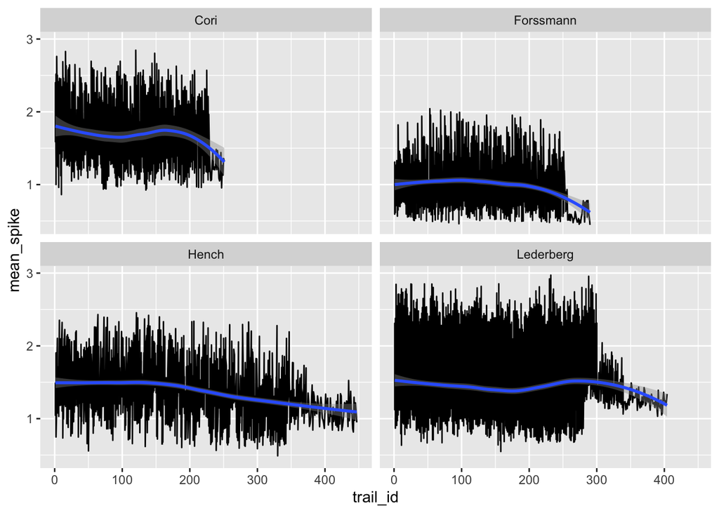

```
## # A tibble: 13 × 8
##    brain_area region_sum_spike region_count region_mean_spike trail_id
##    <chr>                 <dbl>        <int>             <dbl>    <dbl>
##  1 CA1                      62           76             0.816        1
##  2 DG                       61           73             0.836        1
##  3 GPe                      46           63             0.730        1
##  4 MB                      432          275             1.57         1
##  5 MRN                      60           72             0.833        1
##  6 POL                     202          154             1.31         1
##  7 POST                     38           41             0.927        1
##  8 SCm                      38           23             1.65         1
##  9 SCsg                      5           19             0.263        1
## 10 VISl                    152           99             1.54         1
## 11 VISp                     92          105             0.876        1
## 12 VISrl                    62          136             0.456        1
## 13 root                     66           36             1.83         1
## # ℹ 3 more variables: contrast_left <dbl>, contrast_right <dbl>,
## #   feedback_type <dbl>
```

In the first part of this code, I look at a summary of the all 18 sessions and the mean spikes of them all. On average, the mean spikes is about 1.371. It appears that session 13, 3, and session 6 are potential outliers sessions as they have unusually high and low spike averages respectively. Additionally, this further affirms session 10 as being a good session to utilize upon building our model with its mean spike being 1.19.

In the next graph, we can view the brain areas with neurons recorded in each session. Doing this allows for multiple things to happen. Firstly, it provides an insight to the more populous neural area; in this case, root is the most populous neural area which is triggered in session 10. Furthermore, a hypothesis can be formed regarding the neural activity across sessions. Again, root has the most occurences so we could likely predict for other trials. The data was graphed and overall, with the exception of trial 13, there appears to be a negative correlation of trials vs spikes. The spike means decrease as the number of trials increase. This should be later considered in out model

In the next part, an 18 x 2 tibble displays the success rates of the trials. The mean was found early as being 0.7100964. This indicates that session 16 is the best session to use its data to model from. Session 10 is somewhat far from it having a success rate of .620. This could mean for future uses of session 10, some errors/inconsistencies may occur making it not the best model. Additionally, the mouse success rates were also observed with Lederberg having the highest success rate. The data is the put in graphs displaying the rates across trials. Upon observing these graphs, there does not appear to be a clear/concise pattern. However, an argument could be made that the success rates decline as the trials progress. The same is true with the four different mice. This should all be considered when we build our final model.

(Full code in Appendix: Data Integration)

# SECTION 4 PREDICTIVE MODELING

```
##  feedback_type decision   avg_spikes
##  -1:170        1:179    Min.   :0.814
##  1 :277        2:122    1st Qu.:1.059
##                3:113    Median :1.191
##                4: 33    Mean   :1.188
##                         3rd Qu.:1.327
##                         Max.   :1.646
```

```
##
## Call:
## glm(formula = feedback_type ~ ., family = "binomial", data = train)
##
## Coefficients:
##             Estimate Std. Error z value Pr(>|z|)
## (Intercept)  -2.6881     0.8156  -3.296 0.000981 ***
## decision2    -1.0033     0.2923  -3.433 0.000597 ***
## decision3    -0.3784     0.2936  -1.289 0.197431
## decision4    -1.9848     0.4704  -4.219 2.45e-05 ***
## avg_spikes    3.1155     0.6923   4.500 6.78e-06 ***
## ---
## Signif. codes:  0 '***' 0.001 '**' 0.01 '*' 0.05 '.' 0.1 ' ' 1
##
## (Dispersion parameter for binomial family taken to be 1)
##
##     Null deviance: 476.37  on 356  degrees of freedom
## Residual deviance: 436.91  on 352  degrees of freedom
## AIC: 446.91
##
## Number of Fisher Scoring iterations: 4
```

```
## [1] 0.4111111
```

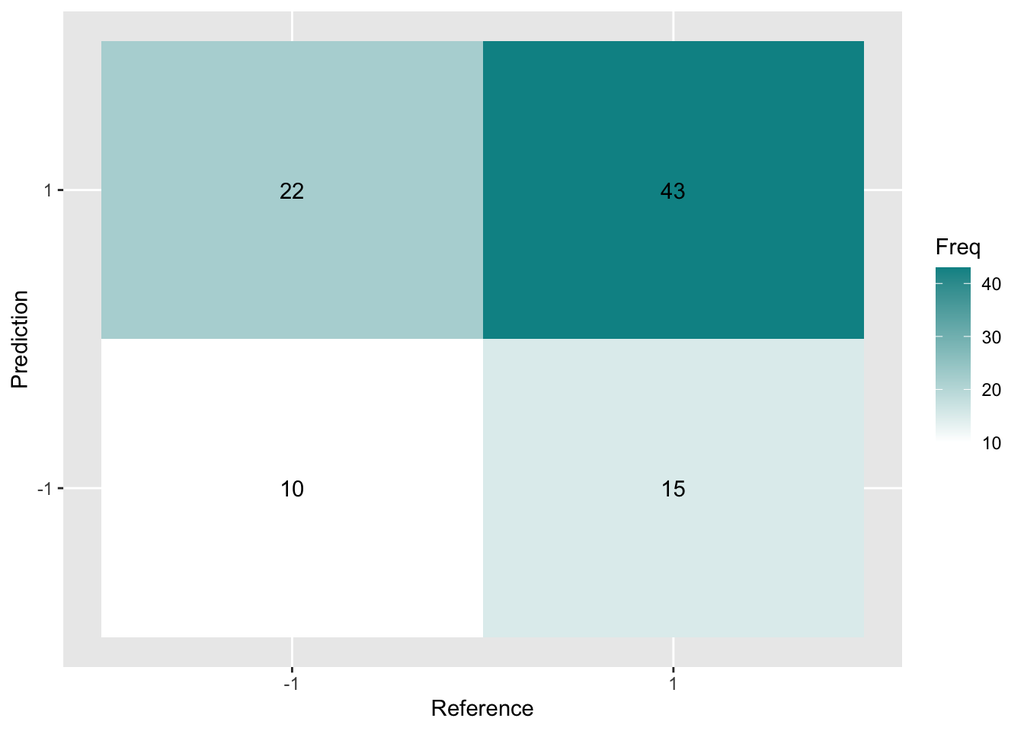

```
## [1] 0.3555556
```

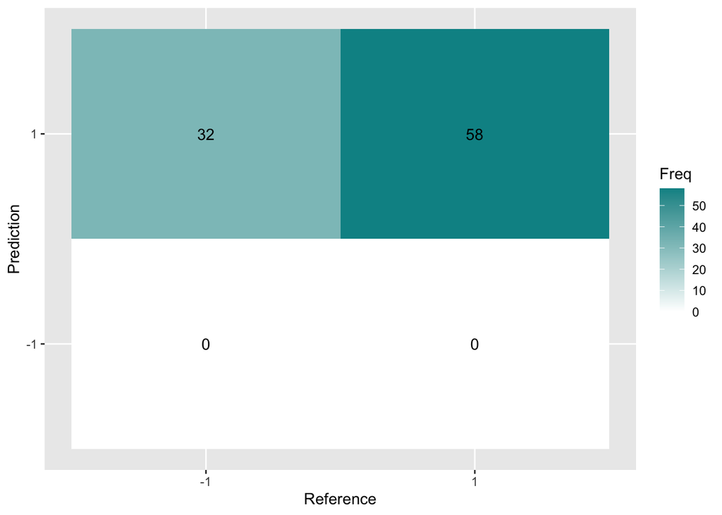

```
##
##   CA1    DG   GPe    MB   MRN   POL  POST  root   SCm  SCsg  VISl  VISp VISrl
##    76    73    63   275    72   154    41    36    23    19    99   105   136
```

```
## # A tibble: 6 × 15
##   feedback_type decision    MB  VISp   SCm  SCsg  POST    DG   MRN   CA1  VISl
##   <fct>         <fct>    <dbl> <dbl> <dbl> <dbl> <dbl> <dbl> <dbl> <dbl> <dbl>
## 1 -1            2        0.816 0.836 0.730  1.57 0.833  1.31 0.927  1.83 1.65
## 2 -1            2        0.658 0.699 0.460  1.29 0.889  1.12 0.951  3.64 0.609
## 3 -1            2        0.855 0.932 0.794  1.74 0.764  1.07 0.976  2.03 0.913
## 4 -1            2        0.908 0.932 0.762  1.30 0.958  1.40 0.634  2.25 0.826
## 5 -1            2        0.816 0.712 0.698  1.58 0.708  1.38 0.732  1.25 0.739
## 6 1             2        0.592 0.726 0.635  1.47 0.819  1.23 1.07   1.67 0.826
## # ℹ 4 more variables: POL <dbl>, root <dbl>, GPe <dbl>, VISrl <dbl>
```

```
##
## Call:
## glm(formula = feedback_type ~ ., family = "binomial", data = train)
##
## Coefficients:
##             Estimate Std. Error z value Pr(>|z|)
## (Intercept)  -4.5254     1.4244  -3.177  0.00149 **
## decision2    -1.1115     0.3414  -3.256  0.00113 **
## decision3    -0.2953     0.3228  -0.915  0.36031
## decision4    -2.2296     0.5261  -4.238 2.26e-05 ***
## MB           -0.2395     0.8448  -0.284  0.77676
## VISp         -1.6197     0.8567  -1.891  0.05867 .
## SCm           2.3996     0.8335   2.879  0.00399 **
## SCsg          1.2937     0.7299   1.773  0.07630 .
## POST          1.7708     0.7182   2.466  0.01367 *
## DG           -0.1436     0.8528  -0.168  0.86627
## MRN           1.2280     0.5962   2.059  0.03945 *
## CA1          -0.1151     0.2361  -0.488  0.62578
## VISl         -0.6011     0.3274  -1.836  0.06638 .
## POL           0.1962     0.2259   0.869  0.38506
## root          1.1045     0.7901   1.398  0.16213
## GPe          -0.6716     0.7688  -0.874  0.38238
## VISrl        -0.4653     1.6476  -0.282  0.77763
## ---
## Signif. codes:  0 '***' 0.001 '**' 0.01 '*' 0.05 '.' 0.1 ' ' 1
##
## (Dispersion parameter for binomial family taken to be 1)
##
##     Null deviance: 476.37  on 356  degrees of freedom
## Residual deviance: 404.84  on 340  degrees of freedom
## AIC: 438.84
##
## Number of Fisher Scoring iterations: 4
```

```
## [1] 0.3555556
```

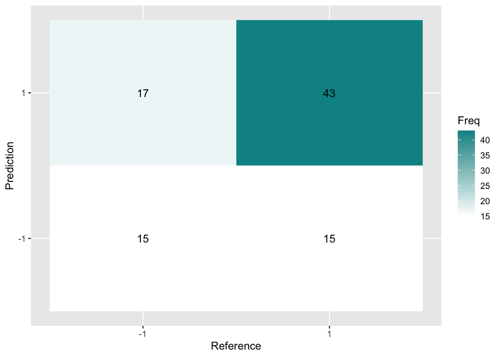

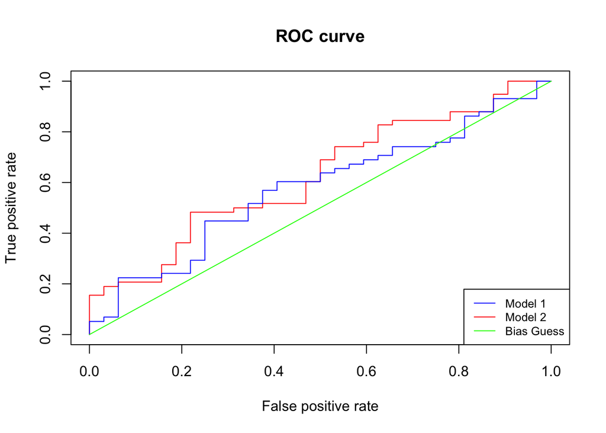

```
## [1] 0.5770474 0.6228448 0.5000000
```

In terms of which is the best model, the ROC curve displays very similar guesses. However, the AUC (Area Under the Curve) is largest with model 2 thus making the better model.

(Full code in Appendix: Data Integration)